# „I like Lord of the Rings, what else should I read?“

## Book Reccomendation Engine

✿ a practice task for DataSentics, by Terézia Ferková ✿

After finishing a good book, a natural question arises in ones mind: "What should I read next?"

**Aim:** In this notebook, I will attempt to solve this problem via a Book Reccomendation Engine. It is bulilt upon the data-set sourced from Institut für Informatik, Universität Freiburg (http://www2.informatik.uni-freiburg.de/~cziegler/BX/).

```python
import pandas as pd
import numpy as np
import matplotlib.pyplot as plt
import csv
from datetime import date
import gc # garbage collector, yay
```

## Importing and Investigating the Dataset

```python
# Import CSV data-set
books = pd.read_csv('BX-Books.csv', sep=';', encoding = "ISO-8859-1", quotechar = '"', escapechar='\\')
users = pd.read_csv('BX-Users.csv', sep=';', encoding = "ISO-8859-1", escapechar='\\')
ratings = pd.read_csv('BX-Book-Ratings.csv', sep=';', encoding = "ISO-8859-1", escapechar='\\')
```

Note - Cleaning the data manually would ensure proper import, for example, the 'BX-Books.csv' file contains semicolons in multiple book and author names, which are problematic.

### Books data

```python
books.head() # look at the first five rows
```

|  | ISBN | Book-Title | Book-Author | Year-Of-Publication | Publisher | Image-URL-S | Image-URL-M | Image-URL-L |
| --- | --- | --- | --- | --- | --- | --- | --- | --- |
| 0 | 0195153448 | Classical Mythology | Mark P. O. Morford | 2002 | Oxford University Press | http://images.amazon.com/images/P/0195153448.0... | http://images.amazon.com/images/P/0195153448.0... | http://images.amazon.com/images/P/0195153448.0... |
| 1 | 0002005018 | Clara Callan | Richard Bruce Wright | 2001 | HarperFlamingo Canada | http://images.amazon.com/images/P/0002005018.0... | http://images.amazon.com/images/P/0002005018.0... | http://images.amazon.com/images/P/0002005018.0... |
| 2 | 0060973129 | Decision in Normandy | Carlo D'Este | 1991 | HarperPerennial | http://images.amazon.com/images/P/0060973129.0... | http://images.amazon.com/images/P/0060973129.0... | http://images.amazon.com/images/P/0060973129.0... |
| 3 | 0374157065 | Flu: The Story of the Great Influenza Pandemic... | Gina Bari Kolata | 1999 | Farrar Straus Giroux | http://images.amazon.com/images/P/0374157065.0... | http://images.amazon.com/images/P/0374157065.0... | http://images.amazon.com/images/P/0374157065.0... |
| 4 | 0393045218 | The Mummies of Urumchi | E. J. W. Barber | 1999 | W. W. Norton &amp; Company | http://images.amazon.com/images/P/0393045218.0... | http://images.amazon.com/images/P/0393045218.0... | http://images.amazon.com/images/P/0393045218.0... |

```python
books.dtypes # what are the datatypes?
```

```
ISBN                   object
Book-Title             object
Book-Author            object
Year-Of-Publication     int64
Publisher              object
Image-URL-S            object
Image-URL-M            object
Image-URL-L            object
dtype: object
```

Let's remove the URL columns, as they are not used in this project. Also rename the remaining for easy use (change "-" to "_", switch to lowercase, remove white space).

```python
books.columns= books.columns.str.strip().str.lower().str.replace("-", "_") # replace - with _
books.drop(columns=['image_url_s','image_url_m','image_url_l'],inplace=True) # drop url columns
books.head()
```

|  | isbn | book_title | book_author | year_of_publication | publisher |
| --- | --- | --- | --- | --- | --- |
| 0 | 0195153448 | Classical Mythology | Mark P. O. Morford | 2002 | Oxford University Press |
| 1 | 0002005018 | Clara Callan | Richard Bruce Wright | 2001 | HarperFlamingo Canada |
| 2 | 0060973129 | Decision in Normandy | Carlo D'Este | 1991 | HarperPerennial |
| 3 | 0374157065 | Flu: The Story of the Great Influenza Pandemic... | Gina Bari Kolata | 1999 | Farrar Straus Giroux |
| 4 | 0393045218 | The Mummies of Urumchi | E. J. W. Barber | 1999 | W. W. Norton &amp; Company |

Values in the `year_of_publication` column can be converted to integers.

Missing and duplicate values must be dealt with. Are there any?

```python
print("There are", books['isbn'].nunique()-books['isbn'].count(), "duplicate book entries in the table.") # count duplicate book ISBN entries
```

```
There are 0 duplicate book entries in the table.
```

```python
zeros_count =(books['year_of_publication'] == 0).sum() # num. of zero values
nan_counts = books['year_of_publication'].isna().sum() # num. of NaN values
print("There are",zeros_count, "cases of '0' and",nan_counts,"NaN values in the year_of_publication column.")
```

```
There are 4619 cases of '0' and 0 NaN values in the year_of_publication column.
```

Let's change zeroes to NaN for less confusion.

```python
books.loc[books['year_of_publication'] == 0,'year_of_publication'] = np.nan #change zeroes to NaN
```

Other columns don't have this issue:

```python
blank_count = (books == '').sum().sum() # count num. of empty strings
print("There are",blank_count, "cases of empty strings in the book_author, book_title and publisher columns.")
```

```
There are 0 cases of empty strings in the book_author, book_title and publisher columns.
```

Let's now look at publication years.

```python
years = books['year_of_publication'].dropna().sort_values() # choose nonempty year entries and sort them
print(years)
```

```
253767    1376.0
227544    1378.0
171826    1806.0
245622    1897.0
108560    1900.0
           ...
193004    2030.0
255426    2037.0
116058    2038.0
80267     2050.0
97830     2050.0
Name: year_of_publication, Length: 266760, dtype: float64
```

Historical books are little relevant for reccomendations. We also see that multiple books were made, according to the table, in the future, which is an error. There are not many, so we shall treat these entries as outliers and remove them.

**Note:** We could correct the invalid future dates, maybe rewrite 2050 to 1950 and such (?).

```python
historical_books = books.loc[books['year_of_publication'] < 1900].index # indices of old books
future_books =  books.loc[books['year_of_publication'] > date.today().year].index # indices of books with future years of publ.
```

```python
count_before = len(books)
books = books.drop(historical_books) # remove old books
books = books.drop(future_books) # remove future books
count_after = len(books)
print("We removed",count_before-count_after,"books, that is",(count_before-count_after)*100/count_before,"percent of entries.")
```

```
We removed 17 books, that is 0.0062643019540937215 percent of entries.
```

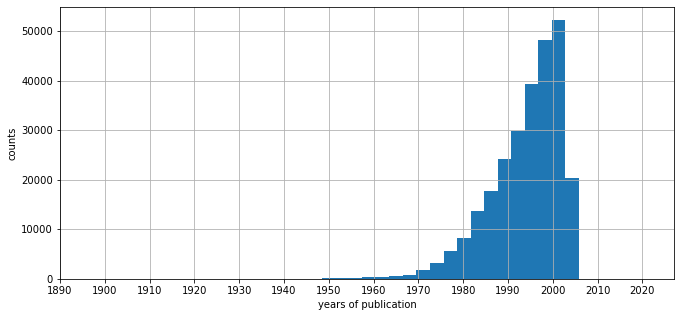

```python
# Histogram of the year_of_publication
ax = books['year_of_publication'].hist(bins=40,figsize=(11,5))
ax.set_xlabel('years of publication')
ax.set_ylabel('counts')
ax.set_xticks(range(1890,2030,10))
plt.show()
```

Now let's adress the book titles.

```python
books['book_title'].value_counts().head() # look at first five most reoccuring book titles
```

```
Selected Poems       27
Little Women         24
Wuthering Heights    21
The Secret Garden    20
Dracula              20
Name: book_title, dtype: int64
```

Let's zoom-in on one of the multiplex titles:

```python
books[books['book_title']=='Dracula'].head()
```

|  | isbn | book_title | book_author | year_of_publication | publisher |
| --- | --- | --- | --- | --- | --- |
| 2959 | 156619301X | Dracula | Bram Stoker | 1994.0 | Dorset Press |
| 5332 | 055321148X | Dracula | Bram Stoker | 1983.0 | Bantam |
| 12754 | 9875021245 | Dracula | Bram Stoker | 2004.0 | Distal |
| 12989 | 0140052801 | Dracula | Bram Stoker | 1992.0 | Penguin USA |
| 52118 | 0451175816 | Dracula | Bram Stoker | 1992.0 | New Amer Library Classics |

There are many instances of one book title being added to the data-set multiple times, each time with a new ISBN number. The reasons are changes in publisher, format, etc.

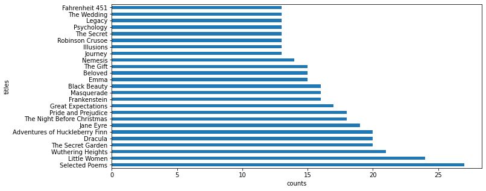

```python
ax = books['book_title'].value_counts()[:25].plot.barh(figsize=(11,5)) # plot top 25 reoccuring books
ax.set_xlabel('counts')
ax.set_ylabel('titles')
plt.show()
```

**Note:** We should unify the multiple entries of one book title under a single unique database number and create a new dataframe. To do this across both books and ratings data, it's better to adress this after making a joined table.

### Users data

```python
users.head()  # look at first five rows
```

|  | User-ID | Location | Age |
| --- | --- | --- | --- |
| 0 | 1 | nyc, new york, usa | NaN |
| 1 | 2 | stockton, california, usa | 18.0 |
| 2 | 3 | moscow, yukon territory, russia | NaN |
| 3 | 4 | porto, v.n.gaia, portugal | 17.0 |
| 4 | 5 | farnborough, hants, united kingdom | NaN |

We tidy up the column names as previously.

```python
users.columns= users.columns.str.strip().str.lower().str.replace("-", "_") # make lower-case, change '-' to '_'
```

```python
users.head()  # look at first five rows of the changed table
```

|  | user_id | location | age |
| --- | --- | --- | --- |
| 0 | 1 | nyc, new york, usa | NaN |
| 1 | 2 | stockton, california, usa | 18.0 |
| 2 | 3 | moscow, yukon territory, russia | NaN |
| 3 | 4 | porto, v.n.gaia, portugal | 17.0 |
| 4 | 5 | farnborough, hants, united kingdom | NaN |

**Note:** `location` data could be separated to get 'town', 'state' and 'country' information. This would be useful in finding out what language our users speak, for example.

We omit the location information.

```python
users.drop(columns=['location'],inplace=True) # remove location column
```

Let's rectify missing values.

```python
zeros_count =(users['age'] == 0).sum() # num. of 0 values
nan_counts = users['age'].isna().sum() # num. of NaN values
print("There are",zeros_count, "cases of '0' and",nan_counts,"NaN values in the age column.")
```

```
There are 416 cases of '0' and 110762 NaN values in the age column.
```

We change zeroes to NaN-s to avoid confusion.

```python
users.loc[users['age'] == 0,'age'] = np.nan # change zeroes to NaN
```

Let's take a look at the ages of our users.

```python
ages = users['age'].dropna().sort_values() # look at entered age values, sorted
print(ages)
```

```
167488      1.0
101324      1.0
245004      1.0
181109      1.0
41869       1.0
          ...
8457      230.0
1578      231.0
58285     237.0
8781      239.0
20856     244.0
Name: age, Length: 167680, dtype: float64
```

Some of the age entries are strange - the user is either a baby or lives well past their 100th birthday.

```python
young_count =(users['age'] < 5).sum() # people too young to rate a book
immortal_counts = (users['age'] > 100).sum() # people either immortal or with false age entry
print("There are",young_count, "users under 5 and",immortal_counts,"immortal users in the age column.")
```

```
There are 466 users under 5 and 366 immortal users in the age column.
```

We change these values to NaN.

```python
users.loc[users['age'] < 5,'age']= np.nan # change age entries lower than 5 to NaN
users.loc[users['age'] > 100,'age']= np.nan # change age entries above 100 to NaN
```

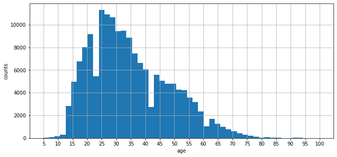

```python
# Histogram of age
ax = users['age'].hist(bins=50,figsize=(11,5))
ax.set_xlabel('age')
ax.set_ylabel('counts')
ax.set_xticks(range(5,105,5))
plt.show()
```

**Note:** We could treat the very old and the very young people as outliers and drop them.

### Ratings data

```python
ratings.head() # look at first five rows
```

|  | User-ID | ISBN | Book-Rating |
| --- | --- | --- | --- |
| 0 | 276725 | 034545104X | 0 |
| 1 | 276726 | 0155061224 | 5 |
| 2 | 276727 | 0446520802 | 0 |
| 3 | 276729 | 052165615X | 3 |
| 4 | 276729 | 0521795028 | 6 |

Clean the table as usual.

```python
ratings.columns= ratings.columns.str.strip().str.lower().str.replace("-", "_") # make lower-case, change '-' to '_'
ratings.head() # look at first five rows of the changed table
```

|  | user_id | isbn | book_rating |
| --- | --- | --- | --- |
| 0 | 276725 | 034545104X | 0 |
| 1 | 276726 | 0155061224 | 5 |
| 2 | 276727 | 0446520802 | 0 |
| 3 | 276729 | 052165615X | 3 |
| 4 | 276729 | 0521795028 | 6 |

```python
ratings['book_rating'] = pd.to_numeric(ratings['book_rating']) # Convert book_rating to int
```

How many unrated / implicitly rated book entries are there?

```python
zeros_count =(ratings['book_rating'] == 0).sum() # num. of 0 values
nan_counts = ratings['book_rating'].isna().sum() # num. of NaN values
print("There are",zeros_count, "cases of '0' and",nan_counts,"NaN values in the ratings column.")
```

```
There are 716109 cases of '0' and 0 NaN values in the ratings column.
```

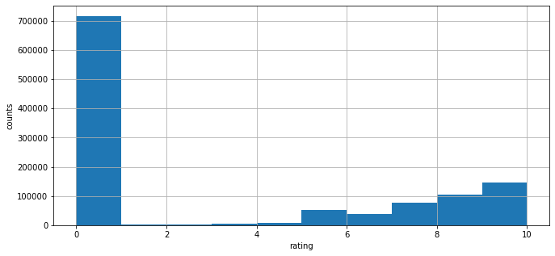

```python
# Histogram of ratings
ax = ratings['book_rating'].hist(figsize=(11,5))
ax.set_xlabel('rating')
ax.set_ylabel('counts')
plt.show()
```

There is a lot of books with rating of zero! These implicit ratings probably have a meaning, but we don't have a way to use them. It is best to remove these entries.

```python
ratings.loc[ratings['book_rating'] == 0,'book_rating'] = np.nan # change zeroes to NaN
```

```python
count_before = len(ratings)
ratings.dropna(subset=['book_rating'], inplace=True) #remove NaN entries
count_after = len(ratings)
print("We removed",(count_before-count_after)*100/count_before,"percent of ratings.")
```

```
We removed 62.28226269373271 percent of ratings.
```

Let's visualize the distribution of the remaining ratings.

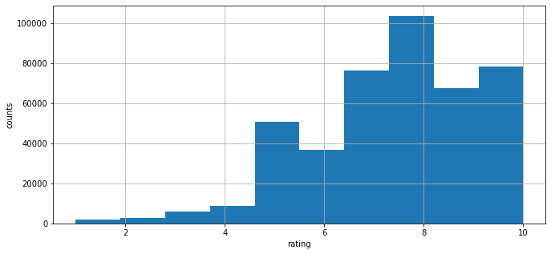

```python
# Histogram of ratings again
ax = ratings['book_rating'].hist(figsize=(11,5))
ax.set_xlabel('rating')
ax.set_ylabel('counts')
plt.show()
```

**Note:** We should be wary of users that give the highest rating every time, since they probably do it out of habit and not genuine feelings about the books. (I also do this)

## Join Books, Users and Ratings

First, create a joined table of `books` and their `ratings`

```python
books_ratings = ratings.join(books.set_index('isbn'), on='isbn') # join books to ratings on ISBN
users_books_ratings = books_ratings.join(users.set_index('user_id'), on='user_id') # join users to the upper on user IDs
print("The size of the final table is:", len(users_books_ratings))
```

```
The size of the final table is: 433671
```

```python
users_books_ratings.head() # look at first five rows of the new dataset
```

|  | user_id | isbn | book_rating | book_title | book_author | year_of_publication | publisher | age |
| --- | --- | --- | --- | --- | --- | --- | --- | --- |
| 1 | 276726 | 0155061224 | 5.0 | Rites of Passage | Judith Rae | 2001.0 | Heinle | NaN |
| 3 | 276729 | 052165615X | 3.0 | Help!: Level 1 | Philip Prowse | 1999.0 | Cambridge University Press | 16.0 |
| 4 | 276729 | 0521795028 | 6.0 | The Amsterdam Connection : Level 4 (Cambridge ... | Sue Leather | 2001.0 | Cambridge University Press | 16.0 |
| 6 | 276736 | 3257224281 | 8.0 | NaN | NaN | NaN | NaN | NaN |
| 7 | 276737 | 0600570967 | 6.0 | NaN | NaN | NaN | NaN | 14.0 |

Let's investigate this new dataset.

```python
users_books_ratings.info() # investigate dataset
```

```
<class 'pandas.core.frame.DataFrame'>
Int64Index: 433671 entries, 1 to 1149779
Data columns (total 8 columns):
 #   Column               Non-Null Count   Dtype
---  ------               --------------   -----
 0   user_id              433671 non-null  int64
 1   isbn                 433671 non-null  object
 2   book_rating          433671 non-null  float64
 3   book_title           383825 non-null  object
 4   book_author          383824 non-null  object
 5   year_of_publication  378041 non-null  float64
 6   publisher            383823 non-null  object
 7   age                  303100 non-null  float64
dtypes: float64(3), int64(1), object(4)
memory usage: 29.8+ MB
```

We can see that there are some missing `book_title` entries, even though we didn't have those in the books dataset. This means that some of the ratings are of books, whose ISBNs were not entered to the books dataset. We remove these ratings since the book information is crucial.

```python
count_before = len(users_books_ratings)
users_books_ratings.dropna(subset=['book_title'], inplace=True)
count_after = len(users_books_ratings)
print("We removed",(count_before-count_after)*100/count_before,"percent of ratings.")
```

```
We removed 11.49396662446878 percent of ratings.
```

### In-between step: further reducing dimensionality

To reduce the dimensionality of the data set, and avoid running into `memory error`, we will filter out rarely rated books and rarely rating users.

```python
# remove all books that were rated less than 5 times
min_book_ratings = 5
filter_books = users_books_ratings['isbn'].value_counts() > min_book_ratings
filter_books = filter_books[filter_books].index.tolist()

# remove all users that rated less than 2 times
min_user_ratings = 2
filter_users = users_books_ratings['user_id'].value_counts() > min_user_ratings
filter_users = filter_users[filter_users].index.tolist()

df_new = users_books_ratings[(users_books_ratings['isbn'].isin(filter_books)) & (users_books_ratings['user_id'].isin(filter_users))]
print('The original data frame shape:\t{}'.format(users_books_ratings.shape))
print('The new data frame shape:\t{}'.format(df_new.shape))
```

```
The original data frame shape:	(383825, 8)
The new data frame shape:	(146913, 8)
```

```python
users_books_ratings = df_new
users_books_ratings.head()
```

|  | user_id | isbn | book_rating | book_title | book_author | year_of_publication | publisher | age |
| --- | --- | --- | --- | --- | --- | --- | --- | --- |
| 16 | 276747 | 0060517794 | 9.0 | Little Altars Everywhere | Rebecca Wells | 2003.0 | HarperTorch | 25.0 |
| 19 | 276747 | 0671537458 | 9.0 | Waiting to Exhale | Terry McMillan | 1995.0 | Pocket | 25.0 |
| 20 | 276747 | 0679776818 | 8.0 | Birdsong: A Novel of Love and War | Sebastian Faulks | 1997.0 | Vintage Books USA | 25.0 |
| 59 | 276772 | 0553572369 | 7.0 | Pay Dirt (Mrs. Murphy Mysteries (Paperback)) | RITA MAE BROWN | 1996.0 | Bantam | NaN |
| 61 | 276772 | 3499230933 | 10.0 | Adressat unbekannt. | Kathrine Kressmann Taylor | 2002.0 | Rowohlt Tb. | NaN |

### I like LOTR, what else should I read?

In this step, I will insert myself into the dataset as a user, who loves the Lord of the Rings book trilogy. I will create a new dataset as to not alter the original one.

```python
# find books from the LOTR trilogy by name and author
fellowship = users_books_ratings[(users_books_ratings['book_title'].str.contains('The Fellowship of the Ring'))&
                                 (users_books_ratings['book_author'].str.contains('Tolkien'))]
towers = users_books_ratings[(users_books_ratings['book_title'].str.contains('The Two Towers'))&
                                 (users_books_ratings['book_author'].str.contains('Tolkien'))]
king = users_books_ratings[(users_books_ratings['book_title'].str.contains('The Return of the King'))&
                                 (users_books_ratings['book_author'].str.contains('Tolkien'))]
```

```python
# select book IDs of the books from the LOTR trilogy
fellowship_id = fellowship['isbn'].iloc[0]
towers_id = towers['isbn'].iloc[0]
king_id = king['isbn'].iloc[0]
```

```python
# create dataframes of me as a user and my ratings
myself = pd.DataFrame({'user_id': [0], 'Age': float("NaN")})
my_ratings = pd.DataFrame({'user_id': [0,0,0], 'isbn': [fellowship_id,towers_id,king_id], 'book_rating':[10,10,10]})
```

```python
# join into one dataframe
my_books_ratings = my_ratings.join(books.set_index('isbn'), on='isbn')
my_users_books_ratings = my_books_ratings.join(users.set_index('user_id'), on='user_id')
```

```python
# add this to the big dataset
users_books_ratings_me_added = pd.concat([my_users_books_ratings,users_books_ratings],ignore_index=True)
```

```python
users_books_ratings_me_added.head() # check if I'm there
```

|  | user_id | isbn | book_rating | book_title | book_author | year_of_publication | publisher | age |
| --- | --- | --- | --- | --- | --- | --- | --- | --- |
| 0 | 0 | 0618002227 | 10.0 | The Fellowship of the Ring (The Lord of the Ri... | J. R. R. Tolkien | 1999.0 | Houghton Mifflin Company | NaN |
| 1 | 0 | 0618002235 | 10.0 | The Two Towers (The Lord of the Rings, Part 2) | J. R. R. Tolkien | 1999.0 | Houghton Mifflin Company | NaN |
| 2 | 0 | 0345272609 | 10.0 | The Return of the King | J. R. R. Tolkien | 1977.0 | Not Avail | NaN |
| 3 | 276747 | 0060517794 | 9.0 | Little Altars Everywhere | Rebecca Wells | 2003.0 | HarperTorch | 25.0 |
| 4 | 276747 | 0671537458 | 9.0 | Waiting to Exhale | Terry McMillan | 1995.0 | Pocket | 25.0 |

## Building a recommendation system

Possible approaches are the following:

**Memory-based Collaborative Filtering -**  
This method calculates the similarity between users or items using the user’s previous data based on ranking. Predictions are calculated by applying statistical techniques to the entire dataset. To forecast what rating would a chosen user give to an item, we would find users similliar to them who have rated this item.

User-based filtering (alternative to item-based) goes like this:

1. choosing other users that are similar to our user U (using cosine similiarity or other)
2. predicting rating of the item I to a user U by calculating the results of aggregating similar users
3. providing recommendations based on the results predicted in stage 2

*Advantages:* it is easy to implement and new data is easily accommodated. However, memory-based collaborative filtering has decreasing performance in data with high sparsity (this is the case for the Book-Crossing dataset) and have limited scalability for large datasets.

**Model-based collaborative filtering -**  
This method uses machine learning algorithms to predict ratings of yet unrated products by customer. These algorithms are further divided into different subsets, i.e., Matrix factorization-based algorithms , deep learning methods, and clustering algorithms.

*Advantages:* we extract some information from the dataset, and use that as a "model" to make recommendations without having to use the complete dataset every time, therefore not as much memory is needed. Also, models tend to give more accurate predictions.

## DIY Memory-based collaborative filtering

**1. choosing similar users to our user U. I will use cosine similiarity metric, calculated as K(X, Y) = <X, Y> / (||X||*||Y||)**

```python
def similiarity(user1,user2):
    """ Calculates similarity score of two user. Chosen similarity metrics is cosine metrics.
        Args :
            user1, user2 (float): two chosen user IDs
        Returns:
            score(float): calculated similarity, in the range (0,1), where 1 is the most similar.
    """
    df = users_books_ratings_me_added[['user_id', 'isbn', 'book_rating']]
    df = df[(df['user_id']==user1) | (df['user_id']==user2)].fillna(0)

    if not user1==user2:
        df_user1 = df.copy()
        df_user1['book_rating'].loc[df_user1['user_id']==user2] = 0

        df_user2 = df.copy()
        df_user2['book_rating'].loc[df_user1['user_id']==user1] = 0
    else:
        df_user1 = df.copy()
        df_user2 = df.copy()

    a =  np.array(df_user1['book_rating'])
    b =  np.array(df_user2['book_rating'])

    score = dot(a, b)/(norm(a)*norm(b))

    return score
```

```python
print(similiarity(0,0))
```

```
0.9999999999999998
```

I will calculate my (`user_id`=0) similiarity to all users.

```python
from collections import defaultdict
```

```python
# Calculate top n similar users using similarity score
similiar_users = defaultdict(list)
for user in users_books_ratings_me_added['user_id'].unique():
        score = similiarity(0,user)
        similiar_users[user].append(score)
```

```python
import itertools

n = 10
top_n_similiar = dict(itertools.islice(dict(sorted(similiar_users.items(), key=lambda item: item[1],reverse=True)).items(), n))
```

**2. predicting rating of the item I to a user U by calculating the results of aggregating similar users**

```python
def predict_item (item,top_n_similiar):
     """ Calculates book rating predictions using the existing prediction of top n users.
        Args :
            item(string): chosen book ID.
            top_n_similiar(dict): keys are user IDs, values are their ratings for chosen book.
        Returns:
            weighted_rating(float): calculated prediction.
    """
    df = users_books_ratings_me_added[['user_id', 'isbn', 'book_rating']]
    top_list_users = top_n_similiar.keys()

    top_list_ratings = []
    for key in top_n_similiar:
        value = df[(df['user_id'] == key) & (df['isbn']==item)]['book_rating'].values[0]
        if value.isnan() :
            top_list_ratings.append(0)
        else:
            top_list_ratings.append(value)
            type(value)

    weights = list(top_n_similiar.values())
    print(weights.type)

    products = []
    for i in range(len(weights)):
        products.append(weights[i] * int(top_list_ratings[i]))

    print(np.array(products))

    weighted_rating = sum(np.array(products)) / sum(np.array(weights))

    return weighted_rating
```

[output not shown]

```python
predict_item('0618002227',top_n_similiar) #test the workability of the function
```

**3. providing recommendations based on the results predicted in stage 2**

```python
# Create dictionary of books and their predicted ratings
book_rankings = defaultdict(list)
for book in users_books_ratings_me_added['book_id'].unique():
        rating = predict_item(book,top_n_similiar)
        title = users_books_ratings_me_added[users_books_ratings_me_added['isbn']==book]['book_title'].unique()[0]
        book_rankings[title].append(rating)
```

```python
print('We suggest you read the following books:')
for title, rating in suggested.items():
    print("-",title,"[",rating[0],"]")
```

[output not shown]

**Note:** This still needs debugging.

## Model-based collaborative filtering

We will be using the `surprise` library and its SVD (singular value decompos.) model.

```python
pip install scikit-surprise #just to be sure
```

```python
from surprise import Dataset
from surprise import dataset
from surprise import accuracy
from surprise import Reader
from surprise import SVD
from surprise.model_selection import train_test_split
from surprise.model_selection import cross_validate
```

We need to transfer our data from pandas dataframe to surprise dataframe. Surprise dataframe must have three columns, user ids, item ids, and ratings in this order.

```python
users_books_ratings_simple = users_books_ratings_me_added[['user_id', 'isbn', 'book_rating']] # strip to three main columns
users_books_ratings_simple.head()
```

|  | user_id | isbn | book_rating |
| --- | --- | --- | --- |
| 0 | 0 | 0618002227 | 10.0 |
| 1 | 0 | 0618002235 | 10.0 |
| 2 | 0 | 0345272609 | 10.0 |
| 3 | 276747 | 0060517794 | 9.0 |
| 4 | 276747 | 0671537458 | 9.0 |

```python
# We need to create a dummy reader
reader = Reader(line_format='user item rating', rating_scale=(1, 10))

# Also, a dummy Dataset class
class MyDataset(dataset.DatasetAutoFolds):
    def __init__(self, users_books_ratings_simple, reader):
        self.raw_ratings = [(user_id, isbn, book_rating, None) for (user_id, isbn, book_rating) in
                            zip(users_books_ratings_simple['user_id'], users_books_ratings_simple['isbn'],
                                users_books_ratings_simple['book_rating'])]
        self.reader=reader

data = MyDataset(users_books_ratings_simple, reader)
```

### In-between step: freeing memory

```python
# I tried to free as much needed memory as possible

#del books_ratings
#del users
#del ratings
#del books
#del my_books_ratings
#del my_users_books_ratings
#del users_books_ratings
#gc.collect()
```

### SVD model

```python
algo = SVD()
```

- Making predictions on the whole dataset, this is an ideal way to go forward. But alas, memory error :'( :

```python
#build full trainset and use cross validation for evaluation

#trainset= data.build_full_trainset()
#SVD_model= algo.fit(trainset)
```

```python
# Predict ratings for all pairs (u, i) that are NOT in the training set.

#testset = trainset.build_anti_testset()
#predictions = algo.test(testset)

# This didn't work as I ran out of memory, even though I garbage collected everyhing.
```

- We make predictions for only a part of the dataset, the data is split automatically. Since we want a particular user (me) to be contained in this part, so this doesn't work:

```python
# Using train test split

#trainset, testset = train_test_split(data, test_size=0.2) # test size is 20% of the dataset

#SVD_model= algo.fit(trainset)
#predictions = SVD_model.test(testset)
#accuracy.rmse(predictions)
```

- Finally, this is a desperate measure. I will cut off most of the dataset to prevent memory error, while keeping the first part, where user with user_id 0 (this is me) is contained.

```python
train_df, __, __, __, __, __= np.array_split(users_books_ratings_simple, 6) # it could work with one sixtth of the dataset
train_data = MyDataset(train_df, reader)
```

```python
train_df.head() #to see if I am in there
```

|  | user_id | isbn | book_rating |
| --- | --- | --- | --- |
| 0 | 0 | 0618002227 | 10.0 |
| 1 | 0 | 0618002235 | 10.0 |
| 2 | 0 | 0345272609 | 10.0 |
| 3 | 276747 | 0060517794 | 9.0 |
| 4 | 276747 | 0671537458 | 9.0 |

```python
# Use custom trainset
trainset= train_data.build_full_trainset()
testset = trainset.build_anti_testset()
SVD_model= algo.fit(trainset)
predictions = algo.test(testset)
```

### Evaluation

```python
accuracy.rmse(predictions)
```

```
RMSE: 0.4793
```

```
0.4792966038561192
```

**Note:** Tuning the hyperparameters of our learning algorithm could give us better accuracy.

### Generating rating predictions and getting top 10

```python
# recieve a prediction for a given user and a book
user = 276747  # user_id
book = '0060517794' # book_isbn

actual = users_books_ratings_simple[(users_books_ratings_simple['user_id']==user) &
                                    (users_books_ratings_simple['isbn']==book)]['book_rating'].values[0]
predicted = SVD_model.predict(user, book, verbose=True)
```

```
user: 276747     item: 0060517794 r_ui = None   est = 8.23   {'was_impossible': False}
```

```python
print("The user has given the book an actual rating of", actual, "while our model predicted it to be", predicted.est)
```

```
The user has given the book an actual rating of 9.0 while our model predicted it to be 8.227057434791117
```

The following function is taken from the surprise documentation.

```python
def get_top_n(predictions, n=10):
    """Return the top-N recommendation for each user from a set of predictions.

    Args:
        predictions(list of Prediction objects): The list of predictions, as
            returned by the test method of an algorithm.
        n(int): The number of recommendation to output for each user. Default
            is 10.

    Returns:
    A dict where keys are user (raw) ids and values are lists of tuples:
        [(raw item id, rating estimation), ...] of size n.
    """

    # First map the predictions to each user.
    top_n = defaultdict(list)
    for uid, iid, true_r, est, _ in predictions:
        top_n[uid].append((iid, est))

    # Then sort the predictions for each user and retrieve the k highest ones.
    for uid, user_ratings in top_n.items():
        user_ratings.sort(key=lambda x: x[1], reverse=True)
        top_n[uid] = user_ratings[:n]

    return top_n
```

```python
def recommended_list(user):
    """
    Args:
        user: The user ID from the dataset.
    Returns:
        List of book titles from the unsimplified users_books_ratings dataframe
    """
    recommended_list = defaultdict(list)

    top_n = get_top_n(predictions, n=10)

    for i in top_n[user]:
        book, rating = i
        title = users_books_ratings_me_added[users_books_ratings_me_added['isbn']==book]['book_title'].unique()[0]
        recommended_list[title].append(rating)
    return recommended_list
```

```python
def we_suggest(user):
    suggested = recommended_list(user)
    print('We suggest you read the following books:')
    for book, rating in suggested.items():
        print("-",book,"[",rating[0],"]")
```

Let's try to recommend books for a random person from the test set.

```python
we_suggest(user=276747)
```

```
We suggest you read the following books:
- Harry Potter and the Sorcerer's Stone (Harry Potter (Paperback)) [ 9.15497205063355 ]
- Fahrenheit 451 [ 9.129365498060363 ]
- A Prayer for Owen Meany [ 9.077709358463292 ]
- The Secret Life of Bees [ 9.059597486195285 ]
- Johnny Got His Gun [ 8.995816430614633 ]
- To Kill a Mockingbird [ 8.989914414420012 ]
- Harry Potter and the Order of the Phoenix (Book 5) [ 8.945550822094203 ]
- A Wrinkle in Time [ 8.943307254468566 ]
- Life of Pi [ 8.929264697536674 ]
- The Giver (21st Century Reference) [ 8.842995475109129 ]
```

**Finally, it's my time!**

```python
we_suggest(user=0) # for me
```

```
We suggest you read the following books:
- A Prayer for Owen Meany [ 9.322708369298901 ]
- Ender's Game (Ender Wiggins Saga (Paperback)) [ 9.30453494313634 ]
- Harry Potter and the Sorcerer's Stone (Harry Potter (Paperback)) [ 9.280934738852508 ]
- The Red Tent (Bestselling Backlist) [ 9.218009353582458 ]
- My Sister's Keeper : A Novel (Picoult, Jodi) [ 9.211175440069326 ]
- The Secret Life of Bees [ 9.19855332232663 ]
- Harry Potter and the Order of the Phoenix (Book 5) [ 9.191687033551995 ]
- Fahrenheit 451 [ 9.162131177081616 ]
- The Cat in the Hat [ 9.138997261111566 ]
- Johnny Got His Gun [ 9.09466211607128 ]
```

## Final thoughts

Many steps could be added to improve on this simple reccomendation engine. The ones that I have thought of are mentioned in the "Note"-s.  
It would be interesting to realize also the Memory-based solution and to compare its performance with our Model-based one. Also `surprise` has more prediction algorithms to choose from, namely SVDpp (taking into account implicit ratings) and KNNBasic (basic nearest neighbors), which would be interesting to try out.

```python
!jupyter nbconvert --to html recommendator.ipynb
```

```
[NbConvertApp] Converting notebook recommendator.ipynb to html
[NbConvertApp] Writing 784264 bytes to recommendator.html
```

### ✿ Thank you for reading this notebook! ✿